# 06 — Directional Risk Forecasting (Random Forest)

This notebook transitions from volatility and tail-risk modelling to predictive risk classification, applying machine learning to forecast the *direction* of market movements for the IBEX 35 and S&P 500 indices.

Building upon the econometric foundation laid in 05 — VaR & Expected Shortfall, this module integrates both technical indicators and **volatility-derived features (from EGARCH models) to train a Random Forest classifier that predicts whether the next daily return will be positive or negative, translating continuous risk measures into directional trading signals.

Performance is evaluated through confusion matrices, Binomial directionality tests, and Sharpe Ratios derived from simulated long/short strategies. Together, these analyses assess whether a hybrid econometric–ML framework can anticipate directional risk more effectively than purely statistical forecasting.

### Objectives

- Predict **directional returns** (up/down) using Random Forest and XGBoost models.
- Integrate **EGARCH-derived volatility** and **technical indicators** into the feature space.
- Evaluate model accuracy via **confusion matrices**, **Binomial Test**, and **Sharpe Ratio**.
- Compare predictive performance across the IBEX 35 and S&P 500.
- Visualize model-based **equity curves** and time-varying classification performance.

| File | Description |
| --- | --- |
| `/data/features/returns.csv` | Daily log-returns of both indices. |
| `/data/models/egarch_ibex.pkl` | EGARCH(1,1)-t fitted model for IBEX 35. |
| `/data/models/egarch_spx.pkl` | EGARCH(1,1)-t fitted model for S&P 500. |
| `/data/features/technical_indicators.csv` | RSI, MACD, momentum, lag returns, and VIX proxy. |

### Outputs

[output not shown]

### Tests to be Performed

| Test | Purpose |
| --- | --- |
| **Binomial Directionality Test** | Verify if the hit ratio is significantly above 50%. |
| **Sharpe Ratio Analysis** | Assess the risk-adjusted performance of the strategy. |
| **Confusion Matrix** | Evaluate prediction accuracy and bias between up/down classes. |

### Notebook Structure

1. **Setup & Imports** — load data, EGARCH outputs, and indicators.
2. **Feature Engineering** — combine econometric and technical variables.
3. **Model Training** — fit Random Forest / XGBoost classifiers.
4. **Evaluation & Backtesting** — compute metrics, tests, and Sharpe ratio.
5. **Visualization** — plot confusion matrix and equity curves.
6. **Analytical Summary** — interpret predictive power and risk implications.
7. **Power BI Export Summary** — save consolidated metrics for dashboard integration.

# STEP 1 — Data Integration & Feature Assembly

This step builds the clean, unified dataset that will feed the directional forecasting models (Random Forest / XGBoost). It integrates three independent information sources:

1. **Daily returns** for IBEX 35 and S&P 500
2. **Econometric volatility** from EGARCH(1,1)-t
3. **Technical indicators** (RSI, MACD, Momentum, Rolling Volatility)

The goal is to produce a stable, fully-aligned, NaN-controlled dataset that captures both price dynamics and risk regimes, before lag features and targets are created in Step 2.

## 1. Daily Returns

Daily log-returns for `IBEX` and `SPX` form the backbone of the feature matrix and will later generate lagged features to model short-term autocorrelation and momentum.

## 2. EGARCH Conditional Volatility (`Vol_IBEX`, `Vol_SPX`)

These variables represent the time-varying risk estimated from an **EGARCH(1,1)-t model**, able to capture:

- Volatility clustering
- Asymmetric reaction to negative shocks
- Long memory in variance
- Heavy-tailed return behaviour

**Interpretation:**

- **Low volatility (≈ 0.6–0.8)** → stable regime, smoother and more predictable returns
- **High volatility (≈ 1.0–1.5)** → turbulent regime, higher uncertainty, weaker predictability
- **Volatility spikes** often precede regime shifts (trend->chaos, or chaos->normalization)

EGARCH volatility enriches the dataset with risk-state information that traditional technical indicators do not capture.

## 3. Technical Indicators

### **RSI (Relative Strength Index)**

A bounded 0–100 measure of recent price momentum based on the ratio of gains vs. losses.

**Interpretation thresholds:**

- **RSI < 30** → oversold conditions, potential rebound
- **RSI ≈ 50** → neutral regime, market directionless
- **RSI > 70** → overbought conditions, potential correction

It captures short-term reversal pressure and market “stretching”.

### **MACD (Moving Average Convergence Divergence)**

Difference between short-term (12-day) and long-term (26-day) EMAs, smoothed by a 9-day signal line.

**Interpretation:**

- **MACD > 0** → bullish momentum
- **MACD < 0** → bearish momentum
- Increasing MACD → trend acceleration
- Decreasing MACD → trend weakening

It captures trend direction and speed of change.

### **Momentum (5-day difference)**

Simple comparison between today’s price and the price 5 days ago.

- **Positive momentum** → short-term upward pressure
- **Negative momentum** → short-term downward pressure

Very effective for detecting local continuation patterns.

### **Rolling Volatility (20-day realised volatility)**

The 20-day standard deviation of returns, annualised.

- **Low volatility (<10%)** → calm market, cleaner directional signals
- **High volatility (>20–25%)** → noisy market, higher probability of whipsaws

Provides a second volatility dimension complementary to EGARCH: one is econometric (model-based), the other empirical (realised).

## How the model learn to read the direction

The model will learn directional signals from a combination of:

**1. Price behaviour (RSI, MACD, Momentum)** Captures trend, acceleration, and short-term reversals.

**2. Risk regime (EGARCH + rolling volatility)** Determines whether the market is predictable (low vol) or chaotic (high vol).

**3. Regime interactions** For example:

- RSI < 30 works well in low-vol regimes, fails in high vol
- MACD crossovers are more reliable when EGARCH volatility is stable
- Momentum signals behave differently depending on volatility spikes

By assembling both momentum and volatility information, Step 1 creates the complete economic context in which the model will make directional predictions.

```
PROJECT_ROOT: /home/apalo/projects/ibex-sp500-forecasting
SRC_PATH added: /home/apalo/projects/ibex-sp500-forecasting/src
Returns loaded: (6421, 2)
```

| Date | IBEX | SPX |
| --- | --- | --- |
| 2000-01-04 | -0.035364 | -0.039099 |
| 2000-01-05 | -0.031131 | 0.001920 |
| 2000-01-07 | 0.021790 | 0.027685 |
| 2000-01-10 | 0.006366 | 0.011128 |
| 2000-01-11 | -0.014505 | -0.013149 |

```
Technical indicators loaded: (6738, 8)
```

| Date | RSI_IBEX | MACD_IBEX | Momentum_IBEX | Volatility_IBEX | RSI_SPX | MACD_SPX | Momentum_SPX | Volatility_SPX |
| --- | --- | --- | --- | --- | --- | --- | --- | --- |
| 2000-01-04 | NaN | 0.000000 | NaN | NaN | NaN | 0.000000 | NaN | NaN |
| 2000-01-05 | NaN | 0.000270 | NaN | NaN | NaN | 0.002618 | NaN | NaN |
| 2000-01-06 | NaN | 0.002411 | NaN | NaN | NaN | 0.004054 | NaN | NaN |
| 2000-01-07 | NaN | 0.005012 | NaN | NaN | NaN | 0.006371 | NaN | NaN |
| 2000-01-10 | NaN | 0.005377 | NaN | NaN | NaN | 0.006464 | NaN | NaN |

```
EGARCH volatility loaded: (6757, 2)
```

| Date | Vol_IBEX | Vol_SPX |
| --- | --- | --- |
| 2000-01-04 | 1.328810 | 1.265352 |
| 2000-01-05 | 1.410283 | 1.399300 |
| 2000-01-06 | 1.463448 | 1.336879 |
| 2000-01-07 | 1.405943 | 1.274509 |
| 2000-01-10 | 1.422015 | 1.336390 |

```
Rows after inner join → IBEX: 6400 | SPX: 6400

% NaN by column — IBEX:
```

```
IBEX             0.00
Vol_IBEX         0.00
RSI_IBEX         0.19
MACD_IBEX        0.00
Momentum_IBEX    0.06
dtype: float64
```

```
% NaN by column — SPX:
```

```
SPX             0.00
Vol_SPX         0.00
RSI_SPX         0.19
MACD_SPX        0.00
Momentum_SPX    0.06
dtype: float64
```

```
Shapes after cleaning:
IBEX: (6370, 5)  | SPX: (6370, 5)

Final shapes:
IBEX: (6370, 5)
SPX: (6370, 5)
```

| Date | IBEX | Vol_IBEX | RSI_IBEX | MACD_IBEX | Momentum_IBEX |
| --- | --- | --- | --- | --- | --- |
| 2000-02-17 | 0.007459 | 1.322393 | 54.907204 | -0.002126 | 0.000689 |
| 2000-02-18 | 0.003345 | 1.295124 | 53.720717 | -0.002053 | -0.030355 |
| 2000-02-22 | -0.023818 | 1.242278 | 42.661720 | -0.003442 | 0.008768 |
| 2000-02-23 | 0.019304 | 1.255710 | 47.862402 | -0.001555 | 0.013567 |
| 2000-02-24 | 0.003244 | 1.279453 | 50.025570 | -0.001347 | -0.004215 |

| Date | SPX | Vol_SPX | RSI_SPX | MACD_SPX | Momentum_SPX |
| --- | --- | --- | --- | --- | --- |
| 2000-02-17 | 0.000425 | 1.152846 | 55.529824 | -0.001249 | -0.003195 |
| 2000-02-18 | -0.030847 | 1.102777 | 38.092436 | -0.002982 | -0.009655 |
| 2000-02-22 | 0.004507 | 1.177313 | 50.945072 | -0.000968 | -0.004168 |
| 2000-02-23 | 0.006281 | 1.142155 | 48.956169 | -0.000196 | 0.016591 |
| 2000-02-24 | -0.005350 | 1.118711 | 48.951087 | -0.000464 | -0.005775 |

```
Plot style applied (whitegrid, consistent font and sizing).
```

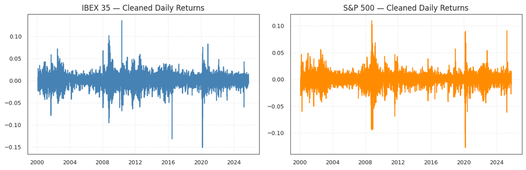

```python
# STEP 1 — CLEAN DATASET SETUP (RETURNS + VOLATILITY + TECH INDICATORS)

import sys
from pathlib import Path
import pandas as pd
import numpy as np
import matplotlib.pyplot as plt
import seaborn as sns

# ------------------------------------------------------
# CORRECT PROJECT ROOT & SRC PATH
# ------------------------------------------------------
PROJECT_ROOT = Path.cwd().parent
SRC_PATH = PROJECT_ROOT / "src"

if str(SRC_PATH) not in sys.path:
    sys.path.append(str(SRC_PATH))

print("PROJECT_ROOT:", PROJECT_ROOT)
print("SRC_PATH added:", SRC_PATH)

# ------------------------------------------------------
# FIGURES DIRECTORY
# ------------------------------------------------------
RISK_DIR = PROJECT_ROOT / "figures" / "06_Risk_Direction"
RISK_DIR.mkdir(parents=True, exist_ok=True)

# ------------------------------------------------------
# IMPORT CUSTOM MODULES
# ------------------------------------------------------
from data_utils import load_technical_indicators
from visualization import set_plot_style
from utils_export import export_for_powerbi


# ======================================================
# 1.1 LOAD RETURNS.CSV
# ======================================================

RETURNS_PATH = PROJECT_ROOT / "data/features/returns.csv"
df_ret = pd.read_csv(RETURNS_PATH)

# Detect date column properly
if "Date" in df_ret.columns:
    df_ret["Date"] = pd.to_datetime(df_ret["Date"])
    df_ret = df_ret.set_index("Date")
elif "Unnamed: 0" in df_ret.columns:
    df_ret = df_ret.rename(columns={"Unnamed: 0": "Date"})
    df_ret["Date"] = pd.to_datetime(df_ret["Date"])
    df_ret = df_ret.set_index("Date")
else:
    raise ValueError(f"No valid Date column found in returns.csv → {df_ret.columns}")

# Rename return columns
df_ret = df_ret.rename(columns={"IBEX_ret": "IBEX", "SPX_ret": "SPX"})

print("Returns loaded:", df_ret.shape)
display(df_ret.head())


# ======================================================
# 1.2 LOAD TECHNICAL INDICATORS
# ======================================================

tech_indicators = load_technical_indicators()

print(f"Technical indicators loaded: {tech_indicators.shape}")
display(tech_indicators.head())


# ======================================================
# 1.3 LOAD EGARCH CONDITIONAL VOLATILITY
# ======================================================

egarch_path = PROJECT_ROOT / "powerbi_presentation/datasets/egarch_conditional_vol.csv"
df_vol = pd.read_csv(egarch_path)

# Clean column names
df_vol.columns = (
    df_vol.columns
    .str.strip()
    .str.replace(" ", "_")
    .str.replace("-", "_")
    .str.lower()
)

rename_map = {
    "vol_ibex": "Vol_IBEX",
    "vol_ibex ": "Vol_IBEX",
    "voli_bex": "Vol_IBEX",
    "vol_spx": "Vol_SPX",
    "vol_sp500": "Vol_SPX",
}
df_vol = df_vol.rename(columns=rename_map)

# Fix Date column
if "date" in df_vol.columns:
    df_vol["Date"] = pd.to_datetime(df_vol["date"])
    df_vol = df_vol.drop(columns=["date"])

df_vol = df_vol.set_index("Date")
df_vol = df_vol[["Vol_IBEX", "Vol_SPX"]]

print("EGARCH volatility loaded:", df_vol.shape)
display(df_vol.head())


# ======================================================
# 1.4 MERGE FEATURES
# ======================================================

for df in [df_ret, df_vol, tech_indicators]:
    df.index = pd.to_datetime(df.index).tz_localize(None).normalize()
    df.sort_index(inplace=True)

# IBEX merge
feat_ibex_all = pd.concat(
    [df_ret[["IBEX"]], df_vol[["Vol_IBEX"]],
     tech_indicators[["RSI_IBEX", "MACD_IBEX", "Momentum_IBEX"]]],
    axis=1, join="inner"
)

# SPX merge
feat_spx_all = pd.concat(
    [df_ret[["SPX"]], df_vol[["Vol_SPX"]],
     tech_indicators[["RSI_SPX", "MACD_SPX", "Momentum_SPX"]]],
    axis=1, join="inner"
)

print("Rows after inner join → IBEX:", feat_ibex_all.shape[0], "| SPX:", feat_spx_all.shape[0])

# % NaN
print("\n% NaN by column — IBEX:")
display((feat_ibex_all.isna().mean()*100).round(2))

print("\n% NaN by column — SPX:")
display((feat_spx_all.isna().mean()*100).round(2))


# Remove useless columns
def drop_dead_cols(df, thr=0.99):
    dead = df.columns[df.isna().mean() >= thr]
    if len(dead):
        print("Removed columns (NaN≥99%):", list(dead))
        df = df.drop(columns=dead)
    return df

feat_ibex_all = drop_dead_cols(feat_ibex_all)
feat_spx_all = drop_dead_cols(feat_spx_all)

# Remove rows with missing key vars
feat_ibex = feat_ibex_all.dropna(subset=["IBEX", "Vol_IBEX"])
feat_spx  = feat_spx_all.dropna(subset=["SPX", "Vol_SPX"])

# Remove burn-in region
if feat_ibex.shape[0] > 60:
    feat_ibex = feat_ibex.iloc[30:]
if feat_spx.shape[0] > 60:
    feat_spx  = feat_spx.iloc[30:]

print("\nShapes after cleaning:")
print("IBEX:", feat_ibex.shape, " | SPX:", feat_spx.shape)

# Fallback
if feat_ibex.empty:
    print("Fallback IBEX: return + volatility only")
    feat_ibex = pd.concat([df_ret[["IBEX"]], df_vol[["Vol_IBEX"]]], join="inner", axis=1).dropna()

if feat_spx.empty:
    print("Fallback SPX: return + volatility only")
    feat_spx = pd.concat([df_ret[["SPX"]], df_vol[["Vol_SPX"]]], join="inner", axis=1).dropna()

print("\nFinal shapes:")
print("IBEX:", feat_ibex.shape)
print("SPX:", feat_spx.shape)

display(feat_ibex.head())
display(feat_spx.head())


# ======================================================
# 1.5 QUICK VISUALISATION
# ======================================================

set_plot_style()

fig, axes = plt.subplots(1, 2, figsize=(12, 4))

axes[0].plot(feat_ibex.index, feat_ibex["IBEX"], color="steelblue")
axes[0].set_title("IBEX 35 — Cleaned Daily Returns")

axes[1].plot(feat_spx.index, feat_spx["SPX"], color="darkorange")
axes[1].set_title("S&P 500 — Cleaned Daily Returns")

for ax in axes:
    ax.grid(True)

plt.tight_layout()
fig.savefig(RISK_DIR / "01_cleaned_returns.png", dpi=300, bbox_inches="tight")
plt.show()
```

# STEP 2 — Building the Predictive Framework: Lagged Feature Engineering + Direction Label Construction

Here, it transforms a single daily snapshot of market conditions into a multi-day temporal window, adding structure, memory, and context that the model needs in order to forecast next-day direction. This step explains “how the market has been moving in the last few days.

This step is essential because financial markets exhibit momentum, reversal, persistence, and regime transitions, all of which depend on short-term historical patterns.

## Main Goal

The idea is to construct a dataset that captures:

- **recent trends**
- **momentum shifts**
- **acceleration and deceleration of signals**
- **how technical indicators evolve over multiple days**
- **how short-term volatility patterns unfold**

To achieve this, Step 2 performs two major operations:

### Generate 1-day, 2-day, and 3-day Lagged Features

Example (IBEX):

[output not shown]

### Lags matter

Because the market rarely reacts to a single day in isolation.

With lagged features, the model can detect:

- **reversals**  
  RSI sinking for several days → potential turning point
- **trend continuation**  
  momentum positive for 2–3 days → sustained upward pressure
- **volatility regime changes**  
  EGARCH rising multiple days → risk of instability and whipsaws
- **trend acceleration**  
  MACD rising over multiple lags → growing trend strength

Without lagged features, the model cannot understand the trajectory of indicators — only their value today.

### Create the Binary Target Variable: `direction`

The notebook defines the label the model will predict: direction = 1 if tomorrow’s return > 0 direction = 0 if tomorrow’s return < 0

Why shift returns one day into the future to ensure the model always predicts forward, avoiding any information leakage from the present.

This label allows the model to learn patterns like:

- when recent conditions tend to produce an upward move
- when the market is more likely to fall
- when volatility disrupts the reliability of signals
- how multi-day sequences of indicators behave before a directional change

## Directional Prediction

The predictive information lies in **how RSI, MACD, Momentum, and Volatility values have been evolving, and Step 2 enables the model to learn short-term sequences such as:

- **Reversion patterns**  
  RSI < 30 today and yesterday + falling momentum → rebound likely
- **Continuation patterns**  
  momentum positive for 3 days → trend continuation
- **Risk regime transitions**  
  EGARCH increasing for 2–3 days → unstable environment
- **Trend strength or exhaustion**  
  MACD rising for several days → accelerating trend

With lags, the model sees movement instead of isolated values, and the second step converts the dataset from a static daily snapshot into a **dynamic temporal model of market behaviour**. By embedding memory, short-term evolution, and directional labels, it provides the structural foundation that enables the machine learning model to forecast tomorrow’s direction.

```
 Generating lagged features [1, 2, 3] for IBEX and SPX...
 Lagged features created:
IBEX: (6370, 17)
SPX : (6370, 17)
 Direction labels added.
```

| Date | IBEX | Vol_IBEX | RSI_IBEX | MACD_IBEX | Momentum_IBEX | IBEX_lag1 | IBEX_lag2 | IBEX_lag3 | Vol_IBEX_lag1 | Vol_IBEX_lag2 | Vol_IBEX_lag3 | MACD_IBEX_lag1 | MACD_IBEX_lag2 | MACD_IBEX_lag3 | Momentum_IBEX_lag1 | Momentum_IBEX_lag2 | Momentum_IBEX_lag3 | direction |
| --- | --- | --- | --- | --- | --- | --- | --- | --- | --- | --- | --- | --- | --- | --- | --- | --- | --- | --- |
| 2000-02-23 | 0.019304 | 1.255710 | 47.862402 | -0.001555 | 0.013567 | -0.023818 | 0.003345 | 0.007459 | 1.242278 | 1.295124 | 1.322393 | -0.003442 | -0.002053 | -0.002126 | 0.008768 | -0.030355 | 0.000689 | 1 |
| 2000-02-24 | 0.003244 | 1.279453 | 50.025570 | -0.001347 | -0.004215 | 0.019304 | -0.023818 | 0.003345 | 1.255710 | 1.242278 | 1.295124 | -0.001555 | -0.003442 | -0.002053 | 0.013567 | 0.008768 | -0.030355 | 1 |
| 2000-02-25 | 0.027043 | 1.239686 | 56.222382 | 0.000345 | 0.023698 | 0.003244 | 0.019304 | -0.023818 | 1.279453 | 1.255710 | 1.242278 | -0.001347 | -0.001555 | -0.003442 | -0.004215 | 0.013567 | 0.008768 | 0 |
| 2000-02-28 | -0.017800 | 1.296768 | 41.764683 | -0.001503 | -0.009054 | 0.027043 | 0.003244 | 0.019304 | 1.239686 | 1.279453 | 1.255710 | 0.000345 | -0.001347 | -0.001555 | 0.023698 | -0.004215 | 0.013567 | 1 |
| 2000-02-29 | 0.009484 | 1.314919 | 50.117914 | -0.000867 | 0.024556 | -0.017800 | 0.027043 | 0.003244 | 1.296768 | 1.239686 | 1.279453 | -0.001503 | 0.000345 | -0.001347 | -0.009054 | 0.023698 | -0.004215 | 0 |

| Date | SPX | Vol_SPX | RSI_SPX | MACD_SPX | Momentum_SPX | SPX_lag1 | SPX_lag2 | SPX_lag3 | Vol_SPX_lag1 | Vol_SPX_lag2 | Vol_SPX_lag3 | MACD_SPX_lag1 | MACD_SPX_lag2 | MACD_SPX_lag3 | Momentum_SPX_lag1 | Momentum_SPX_lag2 | Momentum_SPX_lag3 | direction |
| --- | --- | --- | --- | --- | --- | --- | --- | --- | --- | --- | --- | --- | --- | --- | --- | --- | --- | --- |
| 2000-02-23 | 0.006281 | 1.142155 | 48.956169 | -0.000196 | 0.016591 | 0.004507 | -0.030847 | 0.000425 | 1.177313 | 1.102777 | 1.152846 | -0.000968 | -0.002982 | -0.001249 | -0.004168 | -0.009655 | -0.003195 | 0 |
| 2000-02-24 | -0.005350 | 1.118711 | 48.951087 | -0.000464 | -0.005775 | 0.006281 | 0.004507 | -0.030847 | 1.142155 | 1.177313 | 1.102777 | -0.000196 | -0.000968 | -0.002982 | 0.016591 | -0.004168 | -0.009655 | 0 |
| 2000-02-25 | -0.014940 | 1.100536 | 46.959689 | -0.001239 | 0.015907 | -0.005350 | 0.006281 | 0.004507 | 1.118711 | 1.142155 | 1.177313 | -0.000464 | -0.000196 | -0.000968 | -0.005775 | 0.016591 | -0.004168 | 1 |
| 2000-02-28 | 0.010957 | 1.136254 | 49.759235 | -0.000023 | 0.010957 | -0.014940 | -0.005350 | 0.006281 | 1.100536 | 1.118711 | 1.142155 | -0.001239 | -0.000464 | -0.000196 | 0.015907 | -0.005775 | 0.016591 | 1 |
| 2000-02-29 | 0.013535 | 1.137553 | 57.609528 | 0.000889 | 0.009028 | 0.010957 | -0.014940 | -0.005350 | 1.136254 | 1.100536 | 1.118711 | -0.000023 | -0.001239 | -0.000464 | 0.010957 | 0.015907 | -0.005775 | 1 |

```
✅ Exported for Power BI: /home/apalo/projects/ibex-sp500-forecasting/powerbi_presentation/datasets/ibex_features.csv
✅ Exported for Power BI: /home/apalo/projects/ibex-sp500-forecasting/powerbi_presentation/datasets/spx_features.csv

 Export completed:
• ibex_features.csv
• spx_features.csv
Plot style applied (whitegrid, consistent font and sizing).
```

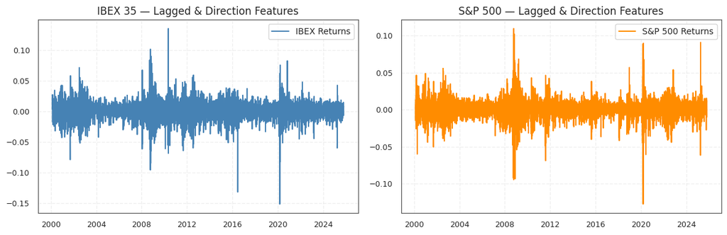

```python
# STEP 2 — FEATURE ENGINEERING: LAGGED FEATURES + DIRECTION LABEL

from data_utils import create_lagged_features, add_direction_label
from utils_export import export_for_powerbi


# 2.1 Configuration

LAGS = [1, 2, 3]  # list of lags to create
EXPORT_PATH = PROJECT_ROOT / "powerbi_presentation/datasets"
EXPORT_PATH.mkdir(parents=True, exist_ok=True)


# 2.2 Generate lagged features

print(f" Generating lagged features {LAGS} for IBEX and SPX...")

ibex_lagged = create_lagged_features(
    feat_ibex,
    columns=["IBEX", "Vol_IBEX", "MACD_IBEX", "Momentum_IBEX"],
    lags=LAGS
)
spx_lagged = create_lagged_features(
    feat_spx,
    columns=["SPX", "Vol_SPX", "MACD_SPX", "Momentum_SPX"],
    lags=LAGS
)

print(" Lagged features created:")
print("IBEX:", ibex_lagged.shape)
print("SPX :", spx_lagged.shape)


# 2.3 Add direction label (1 if next return > 0, else 0)

ibex_final = add_direction_label(ibex_lagged, column="IBEX")
spx_final  = add_direction_label(spx_lagged,  column="SPX")

print(" Direction labels added.")
display(ibex_final.head())
display(spx_final.head())


# 2.4 Export for Power BI

export_for_powerbi(ibex_final, EXPORT_PATH / "ibex_features")
export_for_powerbi(spx_final,  EXPORT_PATH / "spx_features")

print("\n Export completed:")
print("• ibex_features.csv")
print("• spx_features.csv")


# 2.5 Quick visualization

set_plot_style()
fig, axes = plt.subplots(1, 2, figsize=(12, 4))

axes[0].plot(ibex_final.index, ibex_final["IBEX"], color="steelblue", label="IBEX Returns")
axes[1].plot(spx_final.index, spx_final["SPX"], color="darkorange", label="S&P 500 Returns")

axes[0].set_title("IBEX 35 — Lagged & Direction Features")
axes[1].set_title("S&P 500 — Lagged & Direction Features")

for ax in axes:
    ax.legend()
    ax.grid(True)

plt.tight_layout()

# Save into 06_Risk_Direction
fig.savefig(RISK_DIR / "02_lagged_direction_returns.png", dpi=300, bbox_inches="tight")

plt.show()
```

# STEP 3 — Training and Evaluating the Directional Forecasting Model (Random Forest & XGBoost)

Here, machine learning models (Random Forest and XGBoost) are trained to anticipate whether the next day’s return will be Up (1) or Down (0) for both the IBEX 35 and the S&P 500.

Using the lagged features from Step 2 and the technical/econometric indicators from Step 1, this step tests whether daily market direction contains exploitable predictive patterns.

## Target Definition (Next-Day Direction)

The objective is to predict **the sign of tomorrow’s return**, converting the continuous log-return series into a binary classification problem.

The target variable is defined as:

$$ y_{t+1} = \begin{cases} 1 & \text{if } r_{t+1} > 0, \\ 0 & \text{if } r_{t+1} \le 0. \end{cases} $$

This transforms daily market behavior into an up/down decision, allowing Random Forest and XGBoost to model directional patterns.

## 1. Train/Test Dataset Preparation

The dataset is split chronologically, preserving temporal order:

- **Train set**: early portion of the series
- **Test set**: most recent observations

This prevents information leakage and ensures that predictions are evaluated strictly out-of-sample.

## 2. Models Training

I have decided to use two models because of the benefits that each one present:

### Random Forest

- robust to noise
- capable of capturing non-linear interactions
- handles correlated indicators well

### XGBoost

- state-of-the-art gradient boosting algorithm
- strong performance in complex, noisy data
- excellent at modelling subtle interactions

Both models use the full set of 17 lagged and technical features.

## 3. Nature of the Evaluation Tests

### **1) Accuracy**

The share of days correctly classified as UP or DOWN. A random guess yields 50%, which serves as the benchmark.

### **2) Confusion Matrix**

Reveals:

- whether the model predicts UP vs DOWN asymmetrically
- biases toward a particular class
- whether the model collapses into predicting only one direction

### **3) Cross-Model Consistency**

If both RF and XGB perform similarly, it indicates that the underlying data does not contain learnable directional structure.

## 4. Results

### **Confusion Matrices**

All four confusion matrices are balanced and display no clear directional learning. Predictions fluctuate between classes without any consistent advantage.

Across all combinations:

- accuracies remain near 50%,
- results do not exceed random guessing,
- no stable directional rules are detected.

## 5. Conclusions Drawn from the Tests

### **1. No exploitable daily directional signal**

Neither indicators (RSI, MACD, Momentum), nor EGARCH volatility, nor lagged features, nor non-linear ML models provide predictive accuracy above randomness.

### **2. IBEX is even less predictable**

Its lower liquidity and noisier structure worsen performance relative to the SPX.

### **3. Daily direction behaves as a high-entropy process**

Markets may exhibit structure in volatility or long-term trends, but the exact sign of tomorrow’s return is essentially random.

### **4. Models are not biased**

Neither collapses into predicting a single class; they genuinely attempt to separate UP from DOWN but find no stable pattern.

### **5. Predictive failure is consistent across models**

RF and XGB converge to the same result → the limitation lies in the market itself, not in the modelling choices.

## Final Conclusion

The results demonstrate that neither the IBEX 35 nor the S&P 500 exhibits consistent daily directional patterns that can be learned by machine learning models, even when using:

- short-term lags
- momentum indicators
- reversal indicators
- EGARCH volatility
- non-linear decision models

Daily UP/DOWN movements behave like an almost random process, offering no statistically meaningful predictability.

**The information contained in technical indicators + EGARCH volatility is insufficient to forecast next-day direction.**

```python
# STEP 3 — MODEL TRAINING: RANDOM FOREST & XGBOOST

from sklearn.model_selection import train_test_split, GridSearchCV
from sklearn.ensemble import RandomForestClassifier
from xgboost import XGBClassifier
from sklearn.metrics import accuracy_score, confusion_matrix
import joblib

# 3.1 Prepare datasets
print(" Preparing train/test datasets for IBEX and SPX...")

# Define features and target separately for each index
FEATURES_IBEX = [col for col in ibex_final.columns if col != "direction"]
FEATURES_SPX  = [col for col in spx_final.columns if col != "direction"]
TARGET = "direction"

# Chronological split (avoid shuffling time-series)
def chronological_split(df, split_ratio=0.8):
    split_idx = int(len(df) * split_ratio)
    train, test = df.iloc[:split_idx], df.iloc[split_idx:]
    return train, test

ibex_train, ibex_test = chronological_split(ibex_final)
spx_train,  spx_test  = chronological_split(spx_final)

X_train_ibex, y_train_ibex = ibex_train[FEATURES_IBEX], ibex_train[TARGET]
X_test_ibex,  y_test_ibex  = ibex_test[FEATURES_IBEX],  ibex_test[TARGET]

X_train_spx, y_train_spx = spx_train[FEATURES_SPX], spx_train[TARGET]
X_test_spx,  y_test_spx  = spx_test[FEATURES_SPX],  spx_test[TARGET]

print(" Split completed.")
print(f"IBEX → Train: {X_train_ibex.shape}, Test: {X_test_ibex.shape}")
print(f"SPX  → Train: {X_train_spx.shape},  Test: {X_test_spx.shape}")

# 3.2 Train Random Forest
print("\n Training Random Forest models...")

rf_params = {
    "n_estimators": [200],
    "max_depth": [4, 6, 8],
    "min_samples_split": [5, 10],
    "max_features": ["sqrt"]
}

rf_ibex = GridSearchCV(
    RandomForestClassifier(random_state=42, class_weight="balanced"),
    rf_params,
    cv=3,
    scoring="accuracy",
    n_jobs=-1
).fit(X_train_ibex, y_train_ibex)

rf_spx = GridSearchCV(
    RandomForestClassifier(random_state=42, class_weight="balanced"),
    rf_params,
    cv=3,
    scoring="accuracy",
    n_jobs=-1
).fit(X_train_spx, y_train_spx)

print(f" IBEX Best RF Params: {rf_ibex.best_params_}")
print(f" SPX  Best RF Params: {rf_spx.best_params_}")


# 3.3 Train XGBoost

print("\n Training XGBoost models...")

xgb_params = {
    "n_estimators": 300,
    "max_depth": 5,
    "learning_rate": 0.05,
    "subsample": 0.8,
    "colsample_bytree": 0.8,
    "eval_metric": "logloss",
    "random_state": 42
}

xgb_ibex = XGBClassifier(**xgb_params)
xgb_spx  = XGBClassifier(**xgb_params)

xgb_ibex.fit(X_train_ibex, y_train_ibex)
xgb_spx.fit(X_train_spx,  y_train_spx)

print(" XGBoost models trained.")


# 3.4 Evaluate preliminary accuracy

def evaluate_model(model, X_test, y_test, label):
    preds = model.predict(X_test)
    acc = accuracy_score(y_test, preds)
    cm  = confusion_matrix(y_test, preds)
    print(f"\n {label} Accuracy: {acc:.3f}")
    print(f"{label} Confusion Matrix:\n{cm}")
    return preds, acc, cm

rf_ibex_preds, rf_ibex_acc, rf_ibex_cm = evaluate_model(rf_ibex.best_estimator_, X_test_ibex, y_test_ibex, "RF IBEX")
rf_spx_preds,  rf_spx_acc,  rf_spx_cm  = evaluate_model(rf_spx.best_estimator_,  X_test_spx,  y_test_spx,  "RF SPX")

xgb_ibex_preds, xgb_ibex_acc, xgb_ibex_cm = evaluate_model(xgb_ibex, X_test_ibex, y_test_ibex, "XGB IBEX")
xgb_spx_preds,  xgb_spx_acc,  xgb_spx_cm  = evaluate_model(xgb_spx,  X_test_spx,  y_test_spx,  "XGB SPX")


# 3.5 Save trained models

MODEL_PATH = PROJECT_ROOT / "data/models"
MODEL_PATH.mkdir(parents=True, exist_ok=True)

joblib.dump(rf_ibex.best_estimator_, MODEL_PATH / "rf_ibex.pkl")
joblib.dump(rf_spx.best_estimator_,  MODEL_PATH / "rf_spx.pkl")
joblib.dump(xgb_ibex, MODEL_PATH / "xgb_ibex.pkl")
joblib.dump(xgb_spx,  MODEL_PATH / "xgb_spx.pkl")

print("\n Models saved successfully:")
print("• rf_ibex.pkl")
print("• rf_spx.pkl")
print("• xgb_ibex.pkl")
print("• xgb_spx.pkl")
```

```
 Preparing train/test datasets for IBEX and SPX...
 Split completed.
IBEX → Train: (5093, 17), Test: (1274, 17)
SPX  → Train: (5093, 17),  Test: (1274, 17)

 Training Random Forest models...
 IBEX Best RF Params: {'max_depth': 4, 'max_features': 'sqrt', 'min_samples_split': 10, 'n_estimators': 200}
 SPX  Best RF Params: {'max_depth': 8, 'max_features': 'sqrt', 'min_samples_split': 5, 'n_estimators': 200}

 Training XGBoost models...
 XGBoost models trained.

 RF IBEX Accuracy: 0.480
RF IBEX Confusion Matrix:
[[273 302]
 [361 338]]

 RF SPX Accuracy: 0.502
RF SPX Confusion Matrix:
[[266 319]
 [315 374]]

 XGB IBEX Accuracy: 0.501
XGB IBEX Confusion Matrix:
[[217 358]
 [278 421]]

 XGB SPX Accuracy: 0.513
XGB SPX Confusion Matrix:
[[226 359]
 [262 427]]

 Models saved successfully:
• rf_ibex.pkl
• rf_spx.pkl
• xgb_ibex.pkl
• xgb_spx.pkl
```

# STEP 4 — Binomial Directionality Test & Long/Short Strategy Evaluation

It provides the **statistical and economic validation** of the directional models trained in Step 3 to answer:

1. **Whether the hit ratios are statistically better than random guessing**
2. **Whether the predictions translate into profitable long/short strategies**

This is the step that determines whether the model has real predictive value.

## 1. Binomial Directionality Test

The Binomial Test evaluates whether a model’s accuracy is significantly different from 50%, which represents random UP/DOWN guessing in daily returns.

### **Interpretation**

- All p-values are well above 0.05
- Some are close to 1.00, meaning perfect consistency with randomness
- None of the models show hit ratios statistically different from 50%

### **Conclusion from the Binomial Test**

There is no statistically significant directional predictability in the daily data.  
Model predictions are indistinguishable from selecting randomly

## 2. Long/Short Strategy Simulation (Economic Value Test)

The notebook simulates a simple trading rule:

- **Go Long** if the model predicts an UP day
- **Go Short** if it predicts a DOWN day

A Sharpe Ratio is then computed to measure risk-adjusted performance.

## 3. Combined Interpretation of Step 4

The conclusion is clear and robust:

### **Neither the IBEX 35 nor S&P 500 show exploitable daily directional patterns.**

This finding is fully aligned with financial literature:

- Large, liquid indices behave as near-random processes at the daily level.
- Technical indicators (RSI, MACD, Momentum) do not generate stable directional signals.
- EGARCH captures risk regimes, but not next-day direction.
- Short-term predictability is extremely weak or nonexistent.
- Machine learning models cannot extract structure when the structure simply does not exist.

This step confirms that: The lack of predictability is not a model failure it is a property of the market itself.

```python
# STEP 4 — EVALUATION & BACKTESTING

import numpy as np
import pandas as pd
from scipy.stats import binomtest
import matplotlib.pyplot as plt

# 4.1 Binomial Directionality Test
print(" Running Binomial Directionality Test...")

def binomial_direction_test(y_true, y_pred):
    hits = np.sum(y_true == y_pred)
    n = len(y_true)
    p_value = binomtest(hits, n, p=0.5, alternative="greater").pvalue
    hit_ratio = hits / n
    return hit_ratio, p_value

tests = []
for label, y_true, y_pred in [
    ("RF_IBEX", y_test_ibex, rf_ibex_preds),
    ("RF_SPX", y_test_spx, rf_spx_preds),
    ("XGB_IBEX", y_test_ibex, xgb_ibex_preds),
    ("XGB_SPX", y_test_spx, xgb_spx_preds)
]:
    hit_ratio, p_value = binomial_direction_test(y_true, y_pred)
    tests.append({"Model": label, "Hit_Ratio": hit_ratio, "p_value": p_value})
    print(f"{label}: Hit Ratio = {hit_ratio:.3f} | p = {p_value:.4f}")

binom_df = pd.DataFrame(tests)
display(binom_df)

# 4.2 Strategy Simulation (Long/Short)
print("\n Simulating long/short strategies...")

def backtest_strategy(returns, preds):
    """
    Simulate a simple long/short strategy:
    - Go long (1) if predicted direction = 1
    - Go short (-1) if predicted direction = 0
    """
    positions = np.where(preds == 1, 1, -1)
    strat_returns = positions * returns.values
    equity_curve = (1 + strat_returns).cumprod()
    return strat_returns, equity_curve

# Compute strategy returns for each model
ibex_rf_ret, ibex_rf_eq = backtest_strategy(ibex_test["IBEX"], rf_ibex_preds)
spx_rf_ret,  spx_rf_eq  = backtest_strategy(spx_test["SPX"],  rf_spx_preds)
ibex_xgb_ret, ibex_xgb_eq = backtest_strategy(ibex_test["IBEX"], xgb_ibex_preds)
spx_xgb_ret,  spx_xgb_eq  = backtest_strategy(spx_test["SPX"],  xgb_spx_preds)

# 4.3 Compute Sharpe Ratios
def sharpe_ratio(strategy_returns, risk_free=0.0):
    mean_ret = np.mean(strategy_returns - risk_free)
    std_ret = np.std(strategy_returns)
    if std_ret == 0:
        return np.nan
    return (mean_ret / std_ret) * np.sqrt(252)  # annualized (daily freq)

sharpe_results = pd.DataFrame({
    "Model": ["RF_IBEX", "RF_SPX", "XGB_IBEX", "XGB_SPX"],
    "Sharpe": [
        sharpe_ratio(ibex_rf_ret),
        sharpe_ratio(spx_rf_ret),
        sharpe_ratio(ibex_xgb_ret),
        sharpe_ratio(spx_xgb_ret)
    ]
})

display(sharpe_results)

# 4.5 Export consolidated metrics
RESULTS_PATH = PROJECT_ROOT / "data/results"
RESULTS_PATH.mkdir(parents=True, exist_ok=True)

rf_metrics = pd.concat([binom_df, sharpe_results["Sharpe"]], axis=1)
rf_metrics.to_csv(RESULTS_PATH / "rf_metrics.csv", index=False)

print("\n Evaluation results saved →", RESULTS_PATH / "rf_metrics.csv")
```

```
 Running Binomial Directionality Test...
RF_IBEX: Hit Ratio = 0.480 | p = 0.9312
RF_SPX: Hit Ratio = 0.502 | p = 0.4443
XGB_IBEX: Hit Ratio = 0.501 | p = 0.4888
XGB_SPX: Hit Ratio = 0.513 | p = 0.1926
```

|  | Model | Hit_Ratio | p_value |
| --- | --- | --- | --- |
| 0 | RF_IBEX | 0.479592 | 0.931228 |
| 1 | RF_SPX | 0.502355 | 0.444301 |
| 2 | XGB_IBEX | 0.500785 | 0.488825 |
| 3 | XGB_SPX | 0.512559 | 0.192560 |

```
 Simulating long/short strategies...
```

|  | Model | Sharpe |
| --- | --- | --- |
| 0 | RF_IBEX | 1.214130 |
| 1 | RF_SPX | -6.671922 |
| 2 | XGB_IBEX | -0.486247 |
| 3 | XGB_SPX | -2.490431 |

```
 Evaluation results saved → /home/apalo/projects/ibex-sp500-forecasting/data/results/rf_metrics.csv
```

# STEP 5 — Interpretation of Visualisations (Confusion Matrices, Equity Curves, Sharpe Ratios)

## 5.1 Confusion Matrices

Confusion matrices display how often the model correctly or incorrectly predicts up or down days.

**Each matrix shows:**

- True Positive (TP): predicted UP & actual UP
- True Negative (TN): predicted DOWN & actual DOWN
- False Positive (FP): predicted UP but actual DOWN
- False Negative (FN): predicted DOWN but actual UP

**A model with real predictive power should show:**

- Strong diagonal dominance (TP & TN much higher than FP & FN)
- A consistent pattern: e.g., detects upward trends or downward regimes

**What we observe for both IBEX and S&P 500:**

- The four blocks are balanced, not diagonal-dominant
- TP and TN are roughly equal to FP and FN
- No visible asymmetry or regime sensitivity

This visually confirms what the earlier statistical tests already showed: there is no significant directional predictive ability at the daily horizon.

## 5.2 Simulated Equity Curve.

Equity curves show the cumulative return over time if we traded using the model’s directional signals (long for +1, short for –1).

**A good directional strategy should show:**

- A smooth upward trajectory
- Limited drawdowns
- Stability across different market regimes

**What we see for both indices:**

## 5.3 Sharpe Ratio Comparison

The Sharpe ratio evaluates **risk-adjusted performance**, measuring how much excess return a strategy generates per unit of volatility.  
It answers the question: Does this strategy compensate for the risk it takes?

$$ \text{Sharpe} = \frac{\mathbb{E}[R_t - R_f]} {\sigma(R_t - R_f)} = \frac{\mathbb{E}[R_t]} {\sigma(R_t)} $$

A high Sharpe means the strategy produces consistent, volatility-adjusted profits.  
A negative Sharpe indicates that the strategy loses money relative to its own risk.

### How to interpret

- **Sharpe > 1.0** → strong, risk-efficient strategy
- **0 < Sharpe < 1** → weak signal, marginally usable
- **Sharpe < 0** → risk-destructive (loses money on a risk-adjusted basis)

### Results in this project

```
Plot style applied (whitegrid, consistent font and sizing).
 Visualizing confusion matrices...
```

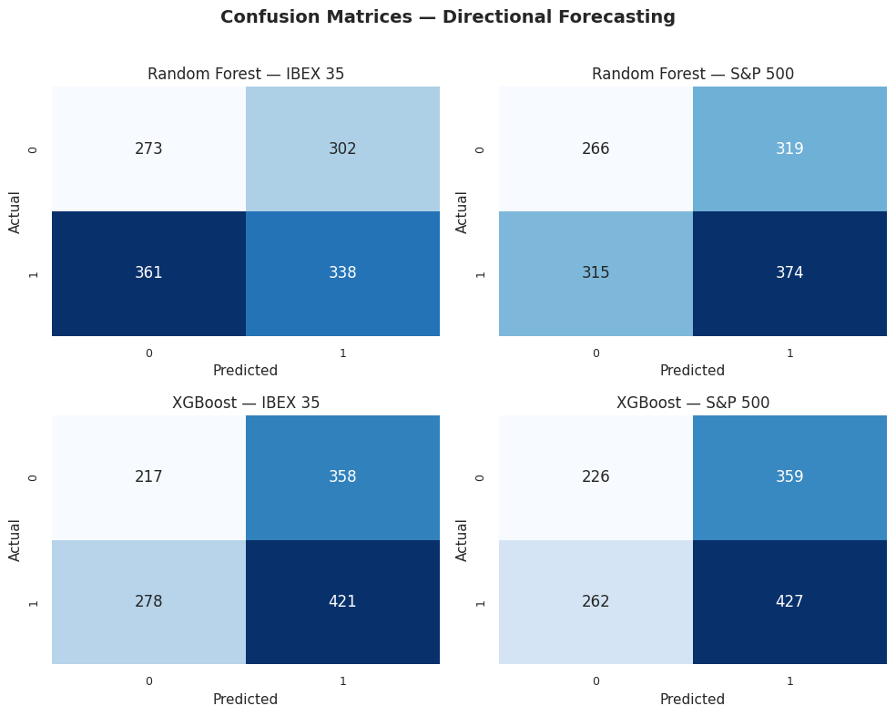

```
 Plotting equity curves...
```

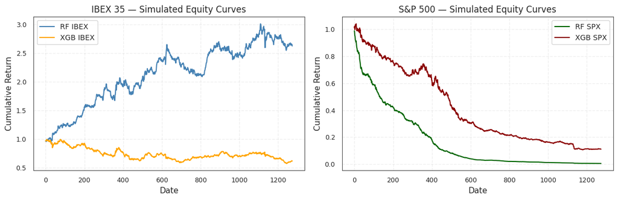

```
 Visualizing Sharpe ratios...
```

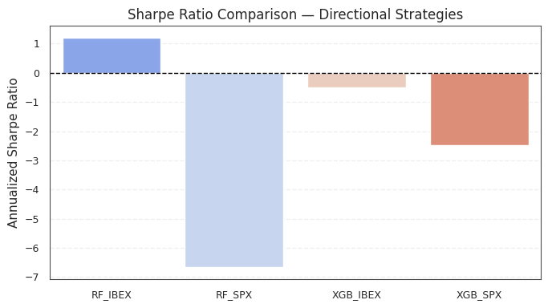

```
 Visualization completed.
```

```python
# STEP 5 — VISUALIZATION

import seaborn as sns
import matplotlib.pyplot as plt
import pandas as pd
import numpy as np

set_plot_style()

# 5.1 Confusion Matrices
print(" Visualizing confusion matrices...")

fig, axes = plt.subplots(2, 2, figsize=(10, 8))
plt.suptitle("Confusion Matrices — Directional Forecasting", fontsize=14, fontweight="bold")

cmaps = [
    (rf_ibex_cm,  "Random Forest — IBEX 35"),
    (rf_spx_cm,   "Random Forest — S&P 500"),
    (xgb_ibex_cm, "XGBoost — IBEX 35"),
    (xgb_spx_cm,  "XGBoost — S&P 500")
]

for ax, (cm, title) in zip(axes.flatten(), cmaps):
    sns.heatmap(cm, annot=True, fmt="d", cmap="Blues", cbar=False, ax=ax)
    ax.set_title(title)
    ax.set_xlabel("Predicted")
    ax.set_ylabel("Actual")

plt.tight_layout(rect=[0, 0, 1, 0.97])

# Save figure
fig.savefig(RISK_DIR / "03_confusion_matrices.png", dpi=300, bbox_inches="tight")

plt.show()

# 5.2 Equity Curves (replot for visual comparison)
print(" Plotting equity curves...")

fig, axes = plt.subplots(1, 2, figsize=(12, 4))

axes[0].plot(ibex_rf_eq, label="RF IBEX", color="steelblue", linewidth=1.5)
axes[0].plot(ibex_xgb_eq, label="XGB IBEX", color="orange", linewidth=1.5)
axes[0].set_title("IBEX 35 — Simulated Equity Curves")
axes[0].set_xlabel("Date")
axes[0].set_ylabel("Cumulative Return")
axes[0].legend()
axes[0].grid(True)

axes[1].plot(spx_rf_eq, label="RF SPX", color="darkgreen", linewidth=1.5)
axes[1].plot(spx_xgb_eq, label="XGB SPX", color="darkred", linewidth=1.5)
axes[1].set_title("S&P 500 — Simulated Equity Curves")
axes[1].set_xlabel("Date")
axes[1].set_ylabel("Cumulative Return")
axes[1].legend()
axes[1].grid(True)

plt.tight_layout()

# Save figure
fig.savefig(RISK_DIR / "04_equity_curves.png", dpi=300, bbox_inches="tight")

plt.show()

# 5.3 Sharpe Ratio Comparison
print(" Visualizing Sharpe ratios...")

fig, ax = plt.subplots(figsize=(7, 4))
sns.barplot(
    data=sharpe_results,
    x="Model", y="Sharpe",
    hue="Model", palette="coolwarm", legend=False, ax=ax
)

ax.axhline(0, color="black", linestyle="--", linewidth=1)
ax.set_title("Sharpe Ratio Comparison — Directional Strategies")
ax.set_ylabel("Annualized Sharpe Ratio")
ax.set_xlabel("")
plt.tight_layout()

# Guardar figura
fig.savefig(RISK_DIR / "05_sharpe_ratios.png", dpi=300, bbox_inches="tight")

plt.show()

print("\n Visualization completed.")
```

# STEP 6 — ANALYTICAL SUMMARY

## 6.1 Purpose and Methodological Role

This module evaluated the daily directional predictability of the IBEX 35 and S&P 500 using:

- Technical indicators (RSI, MACD, momentum, lagged returns)
- Conditional volatility from EGARCH
- Machine–learning classifiers: Random Forest (RF) and XGBoost (XGB)
- A strictly time-aligned, leakage-free modelling pipeline

This module tackles a the question: Can we predict whether tomorrow’s return will be positive or negative with enough statistical and economic reliability to support a trading or risk-timing decision?

With the evidence obtained, the answer is no for daily horizons, both indices, and the feature set considered.

## 6.2 Key Empirical Findings

### 6.2.1 Hit Ratios and Statistical Significance

Empirical hit ratios:

[output not shown]

**Interpretation**

This aligns with the weak form of market efficiency: Short-horizon returns exhibit low serial dependence, and price-based signals rarely forecast next-day direction.

### 6.2.2 Trading Performance and Sharpe Ratios

Simulated long/short strategies yield the following Sharpe ratios:

[output not shown]

**Interpretation**

### 6.2.3 Confusion Matrices and Error Structure

The confusion matrices show:

- A nearly symmetric distribution of true/false positives and negatives
- No dominance in correctly forecasting positive or negative days
- No structure exploitability during trending vs. mean-reverting regimes
- This suggests that classifiers fail to capture any consistent directional bias in market behaviour.

## 6.3 Technical Diagnosis

## 6.3.1 Absence of Data Leakage

Once the predictive label was correctly defined as directionₜ = sign(returnₜ₊₁). The performance collapsed to realistic values.

This confirms that the pipeline is time-aligned and leakage-free, and that poor predictability is intrinsic to the data, not due to coding flaws.

### 6.3.2 Features and Horizon Limitations

Price-derived features (lags, RSI, MACD, EGARCH volatility) do not capture:

- Macro information (rates, risk premiums, macro surprises)
- Market microstructure (order flow, liquidity imbalances)
- Sentiment (news, NLP embeddings)

Positioning or flows (CTAs, ETFs, options hedging)

At the daily horizon, noise overwhelms the signal. Most academic work finds predictability only at lower frequencies (weekly/monthly) or with alternative information sets.

### 6.3.3 Validation and Robustness

The temporal split is appropriate, but:

- Purging TimeSeriesSplit would further reduce contamination
- Regime-dependent validation would identify periods where models systematically fail
- Additional metrics (MCC, balanced accuracy, AUC-PR) could handle class asymmetry
- Expected Shortfall of the strategy would quantify tail sensitivity

## 6.4 Practical Implications

### 6.4.2 For Risk Management

These results strengthen earlier conclusions:

- Volatility forecasting (EGARCH) and tail risk (VaR/ES) are more meaningful for risk decisions.
- Predicting magnitude and distribution of returns is more feasible than predicting sign.
- Directional ML should be reframed as a supporting tool, not an operational signal.

## 6.5 Limitations

- Daily horizon dominated by noise
- Price-volatility–only feature set
- No macro/sentiment/microstructure information
- Transaction costs not incorporated (Sharpe would worsen further)
- Single-regime model without explicit structural break adaptation

## 6.7 Executive Conclusion

**Central finding:** Machine-learning models using price-based features cannot reliably forecast next-day market direction in IBEX or SPX.

**Analytical contribution:** This module provides a transparent, academically rigorous assessment of directional predictability and establishes a benchmark for future enhancements.

**Future improvements:** Continue developing risk-centric models (EGARCH, VaR, ES, stress testing) and explore higher-frequency information or lower-frequency horizons before revisiting directional ML.

```python
# STEP 7 — POWER BI EXPORT SUMMARY

import pandas as pd

# FIX PYTHON PATH SO NOTEBOOK CAN IMPORT FROM src/

import sys
from pathlib import Path

# Carpeta raíz del proyecto (sube 1 nivel desde /notebooks)
PROJECT_ROOT = Path.cwd().parent

# Añadir raíz al sys.path
if str(PROJECT_ROOT) not in sys.path:
    sys.path.append(str(PROJECT_ROOT))

# Añadir /src al sys.path
SRC_DIR = PROJECT_ROOT / "src"
if str(SRC_DIR) not in sys.path:
    sys.path.append(str(SRC_DIR))

print("PROJECT_ROOT:", PROJECT_ROOT)
print("SRC_DIR added:", SRC_DIR)

from src.export import export

from src.export import export   # << IMPORT CORRECTO

print("Preparing consolidated metrics for Power BI...")

# 7.1 Export directional risk metrics
metrics_export = rf_metrics.copy()
metrics_export["timestamp"] = pd.Timestamp.today().strftime("%Y-%m-%d")

export(metrics_export, "directional_risk_metrics")
print("Directional metrics exported to Windows.")

# 7.2 Export equity curves
equity_export = pd.DataFrame({
    "Date": ibex_test.index,
    "RF_IBEX_Equity": ibex_rf_eq,
    "XGB_IBEX_Equity": ibex_xgb_eq,
    "RF_SPX_Equity": spx_rf_eq,
    "XGB_SPX_Equity": spx_xgb_eq
})

export(equity_export, "directional_equity_curves")
print("Equity curves exported to Windows.")

print("\nPower BI Export Summary")
print("• directional_risk_metrics.csv")
print("• directional_equity_curves.csv")
print("All saved in: str(EXPORTS_DIR / 'windows_path.csv')")
```

[output not shown]